# Chi Squared Test

```r
# Use this R-Chunk to import all your datasets!
Guns <- read_csv("https://github.com/kctolli/MATH335/raw/master/Case_Studies/Case_Study_04/analysis/full_data.csv") %>%
  select(-X1) %>% na.omit() %>%
  filter(!is.na(intent)) %>% filter(!is.na(age)) %>%
  select(intent, age, race, education, sex)
```

```r
View(Guns)
```

## Background

The world is a dangerous place. During 2015 and 2016 there was a lot of discussion in the news about police shootings. FiveThirtyEight reported on gun deaths in 2016. As leaders in data journalism, they have posted a clean version of this data in their [GitHub](https://github.com/fivethirtyeight/guns-data) repo called full_data.csv for us to use. The data of the gun deaths was recorded over the coarse of two years (2012-2014).

## Hypotheses & Data Analysis

### Is intent associated with education regardless of race?

$$H_{01}:\ \text{Intent and education are not associated.}$$

$$H_{a1}:\ \text{Intent and education are associated.}$$

```r
# Test H_{01}:
gun1 <- table(setDT(Guns %>% select(intent, education)))
chi.gun1 <- chisq.test(gun1); chi.gun1
```

```
##
##  Pearson's Chi-squared test
##
## data:  gun1
## X-squared = 7630.7, df = 9, p-value < 2.2e-16
```

```r
pander5(chi.gun1$expected)
```

|  | BA+ | HS/GED | Less than HS | Some college |
| --- | --- | --- | --- | --- |
| **Accidental** | TRUE | TRUE | TRUE | TRUE |
| **Homicide** | TRUE | TRUE | TRUE | TRUE |
| **Suicide** | TRUE | TRUE | TRUE | TRUE |
| **Undetermined** | TRUE | TRUE | TRUE | TRUE |

All expected counts are greater than 5, so the requirements are met.

```r
pander(chi.gun1$residuals)
```

|  | BA+ | HS/GED | Less than HS | Some college |
| --- | --- | --- | --- | --- |
| **Accidental** | -4.415 | -2.132 | 7.611 | -1.198 |
| **Homicide** | -43.62 | 5.094 | 48.85 | -22.21 |
| **Suicide** | 32.74 | -3.265 | -37.17 | 16.39 |
| **Undetermined** | -1.146 | -1.058 | 1.938 | 0.4351 |

The residuals allow us to visualize how the points follow the test. The values show how far off the data is from the expected values.

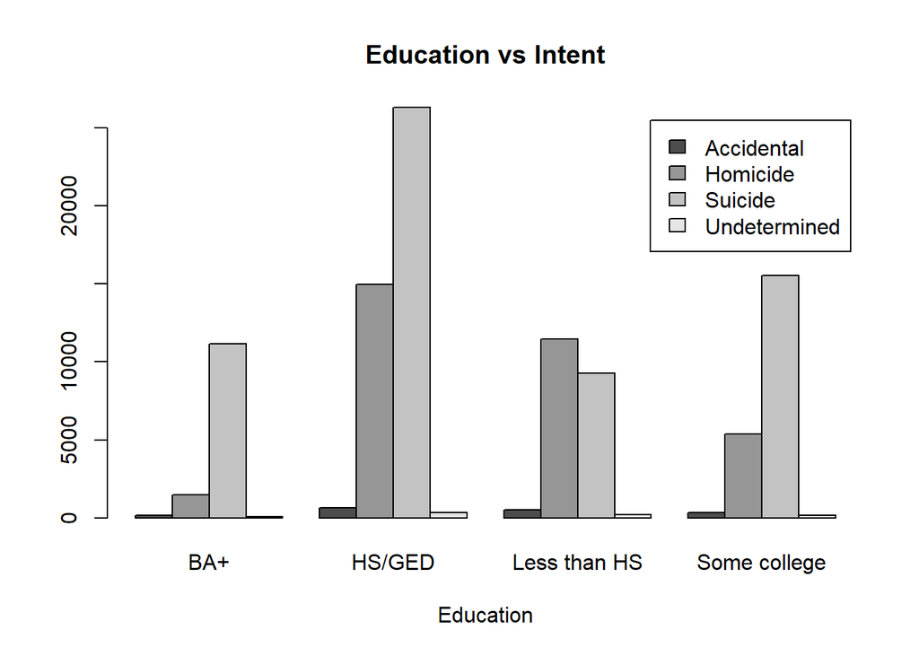

```r
barplot(gun1, beside=TRUE, legend.text=TRUE, xlab="Education", main="Education vs Intent")
```

### Is intent associated with race?

$$H_{02}:\ \text{Intent and race are not associated.}$$

$$H_{a2}:\ \text{Intent and race are associated.}$$

```r
# Test H_{02}:
gun2 <- table(setDT(Guns %>% select(race, intent)))
chi.gun2 <- chisq.test(gun2); chi.gun2
```

```
##
##  Pearson's Chi-squared test
##
## data:  gun2
## X-squared = 40944, df = 12, p-value < 2.2e-16
```

```r
pander5(chi.gun2$expected)
```

|  | Accidental | Homicide | Suicide | Undetermined |
| --- | --- | --- | --- | --- |
| **Asian/Pacific Islander** | TRUE | TRUE | TRUE | TRUE |
| **Black** | TRUE | TRUE | TRUE | TRUE |
| **Hispanic** | TRUE | TRUE | TRUE | TRUE |
| **Native American/Native Alaskan** | TRUE | TRUE | TRUE | TRUE |
| **White** | TRUE | TRUE | TRUE | TRUE |

All expected counts are greater than 5, so the requirements are met.

```r
pander(chi.gun2$residuals)
```

|  | Accidental | Homicide | Suicide | Undetermined |
| --- | --- | --- | --- | --- |
| **Asian/Pacific Islander** | -1.888 | 4.163 | -2.734 | -0.07923 |
| **Black** | -3 | 128.1 | -92.68 | -4.594 |
| **Hispanic** | 0.1469 | 43.33 | -31.75 | 0.2446 |
| **Native American/Native Alaskan** | 1.767 | -0.1479 | -0.4653 | 2.568 |
| **White** | 1.782 | -92.25 | 66.93 | 2.344 |

The residuals allow us to visualize how the points follow the test. The values show how far off the data is from the expected values.

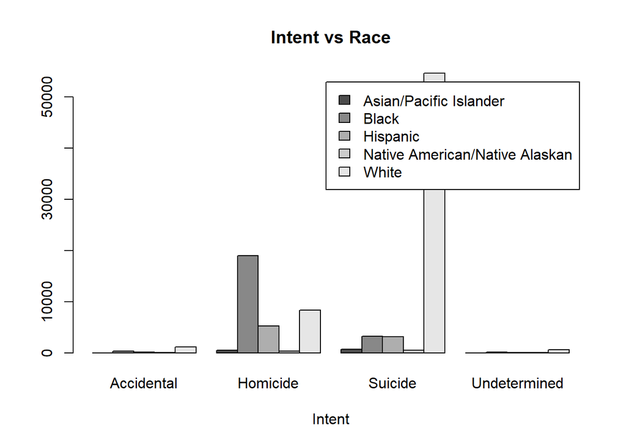

```r
barplot(gun2, beside=TRUE, legend.text=TRUE, xlab="Intent", main="Intent vs Race")
```

### Is race associated with education?

$$H_{03}:\ \text{Education and race are not associated.}$$

$$H_{a3}:\ \text{Education and race are associated.}$$

```r
# Test H_{03}:
gun3 <- table(setDT(Guns %>% select(race, education)))
chi.gun3 <- chisq.test(gun3); chi.gun3
```

```
##
##  Pearson's Chi-squared test
##
## data:  gun3
## X-squared = 8600.2, df = 12, p-value < 2.2e-16
```

```r
pander5(chi.gun3$expected)
```

|  | BA+ | HS/GED | Less than HS | Some college |
| --- | --- | --- | --- | --- |
| **Asian/Pacific Islander** | TRUE | TRUE | TRUE | TRUE |
| **Black** | TRUE | TRUE | TRUE | TRUE |
| **Hispanic** | TRUE | TRUE | TRUE | TRUE |
| **Native American/Native Alaskan** | TRUE | TRUE | TRUE | TRUE |
| **White** | TRUE | TRUE | TRUE | TRUE |

All expected counts are greater than 5, so the requirements are met.

```r
pander(chi.gun3$residuals)
```

|  | BA+ | HS/GED | Less than HS | Some college |
| --- | --- | --- | --- | --- |
| **Asian/Pacific Islander** | 15.79 | -7.705 | -5.113 | 3.691 |
| **Black** | -39.82 | 7.474 | 35.49 | -15.13 |
| **Hispanic** | -21.84 | -10.05 | 43.52 | -12.5 |
| **Native American/Native Alaskan** | -7.017 | 0.07508 | 4.32 | 1.013 |
| **White** | 30.17 | 0.3076 | -36.7 | 12.89 |

The residuals allow us to visualize how the points follow the test. The values show how far off the data is from the expected values.

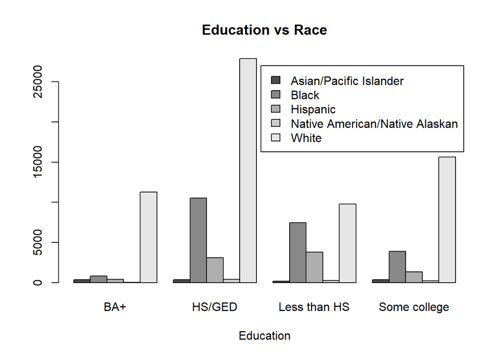

```r
barplot(gun3, beside=TRUE, legend.text=TRUE, xlab="Education", main="Education vs Race")
```

## Interpretation

With each of the of the tests we learn what data is like for the each of the data. For the 3 tests the p-value is the same at < 2.2e-16. Each of the tests did pass the greater than 5 test (If this failed, it will still be appropriate as long as all expected counts are at least 1 and the average expected count is at least 5).